# Microrrelatos Ababol Edizions XIII (2026)

[Ababol Edizions](https://ababoledizions.blogspot.com/)

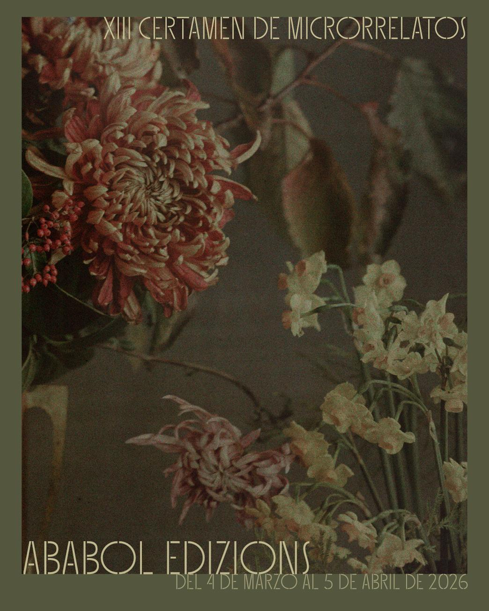

Decimotercer certamen de microrrelatos

Ababol Edizions

8 de abril de 2026

Huesca

1 La gran decisión

2 Bodegón del almirante

3 Vivir y dejar vivir

4 De esperanza

5 De vida

6 Sin título

7 Vendaval

8 Mensajes

9 Hogar

10 Basta Ya!!

11 Vestigio

12 Fana

13 De vergüenza

14 El bosque

15 La aldea

16 ¿Y si sí?

17 Quienes solíamos ser

18 Tempus fugit

19 Tiempo de ababoles

20 Aquí no hay quien viva

21 Henrietta Swan Leavitt, 1912

22 La versión de Safo

23 Sasa del Abadiado

24 Qué desasosiego

25 ¿Quién mueve los hilos?

26 Monstruos para todas las edades

27 Conexión

28 La verdad

29 La costura del silencio

30 Aún anónima

31 Tinieblas

32 Gen Z

33 Sin título

34 Sin título

35 ¿EL ser humano HA PASADO A LA HISTORIA?

36 La gota que colmó el agua

# 1

# La gran decisión

Aquella enorme y oscura sala me resultaba familiar. Gradualmente una cálida luz comenzó a bañar la estancia y los recuerdos volvieron de golpe. ¡No! ¡Otra vez, no! Observé el desfile de farolillos de colores flotando en el techo. Era un espectáculo cautivador y aterrador al mismo tiempo.

—¿Cómo estás, Bernardo?  
—Con pocas ganas de verte.  
—Siento escuchar eso… Yo sí quería verte. Ha llegado tu turno.  
—¡Pero si estaba muy bien aquí! He evolucionado mucho desde que empecé… ¡Incluso he aprendido a lavarme los dientes a diario!  
—Bernardo, nunca quieres marchar y luego no quieres volver, como los críos con la ducha. ¡Toca reencarnarse y punto! Además, esta vez tengo verdaderas maravillas. ¡Con lo enamoradizo que eres seguro que alguna llama tu atención! Si no te interesa volver a ser un humano siempre puedo mandarte al planeta BP-1378.  
—¡Ah, no! ¡Ahí no queda un vestigio de afecto!

Paseé entre los farolillos mirando al suelo. Sabía que si los contemplaba volvería a pasar… pero terminé alzando la vista. De repente uno de ellos me pareció inusualmente hermoso. En un instante me atravesaron todas las emociones que caben en una vida humana. Ya no había escapatoria.

# 2

# Bodegón del almirante

El otro día en el suplemento dominical de la LA Times, Chuck había visto el listado de los 100 restaurantes dónde uno tenía haber comido antes de morir. El único sitio en el que todavía no había estado era el Bodegón del Almirante, en Bollullos Par del Condado.

Imposible que no lo conozca, pensó, y ya que había viajado por todo el planeta. Sin más, fletó un Uberjet-Plus, que le llevaba a este sitio en Huelva, con servicio de limusina incluido.

—Bienvenido Sr. Norris, ¿cómo podemos deleitarle?

—Póngame el menu de la casa por el que se debería conocer a este establecimiento en Los Ángeles, mandó Chuck.

Acto seguido le sirvieron una patata asada con aceite, ajo y perejil, una ensalada de ventresca de escabeche, un surtido de MorSalCho (morcilla, salchichón y chorizo a la plancha, entiéndese), y un bocadillo completo compuesto de panceta, queso y paté.

Chuck Norris no sería él mismo si no acabase todo. Después del último bocado, respiró profundo y cayó desplomado.

Los servicios de emergencia no pudieron reanimarle ni en todo el camino al hospital. El forense indicó en el certificado de defunción como causa de la muerte: vestigio de colesterol en la aorta.

## Trigliceraptor

# 3

# Vivir y dejar vivir

Era el día de la fiesta nacional. Le tocó estar de guardia. Todas sus compañeras comadronas le habían comentado que ninguna paciente estaba a punto de caramelo. Estaba esperando una jornada tranquila. Cerca de las 5 de la tarde, le entró el aviso del sistema. Rotura de aguas en Valdecabras. Rural, simplemente rural. ¿No era el pueblo dónde vivía éste ahora? Todos los servicios bajo mínimos por las fiestas, se preparó para un parto en casa, su especialidad.

Al llegar vio confirmada su sospecha. Toda la casa repleta de fotos con su ex y su cliente de emergencia. Qué cabrón, pensó. ¿Y ahora me toca sacar su nuevo churumbel? Sus ganas de trabajar acaban de reducirse a mínimos. Manda ovarios que me toca convertirle en padre otra vez. Qué remedio...

—¿Y el padre?, preguntó enfadada

—De puente con el velero. Salgo de cuentas en 6 semanas, contestó la parturienta.

Las contracciones de la paciente le ayudaron a bajar su cabreo. La criatura no tiene la culpa de su divorcio.

Con un vestigio de humanidad y ética profesional, decidió cortar el cordón umbilical después, y no antes de llevar a cabo el parto del hermanastro de sus hijas.

## MC Lacuna

# 4

# De esperanza

El juez reanudó la sesión: --El fiscal de la acusación particular de la Asociación de Amigos de las Biosferas puede proceder con su alegato final.

El susodicho reptó elegantemente hasta el estrado y comenzó:

—Casi 5 millones de larvas menores de 5 años muertas en un año —niños las llaman— por causas evitables. Un sistema económico que se basa en el crecimiento exponencial. Calentamiento atmosférico desbocado. Ningún año sin conflicto armado durante centurias. No son mis datos. Son datos de organizaciones humanas transnacionales.

—Mi estimado colega defensor les dirá que la Humanidad es también capaz de lo mejor, de los sentimientos más nobles y de los más desinteresados sacrificios. Les hablará del Amor. Sin embargo, desde que se observa al Homo Sapiens, nunca han logrado separar el trigo de la paja. No hay vestigio de esperanza para el planeta según todos los modelos matemáticos.

Hizo una pausa dramática.

—Por todo lo anterior, nuestra demanda es firme: clasificación inmediata como plaga parasitaria y tratamiento urgente para salvar la biosfera terrestre.

Mientras se retiraba habló el juez: —El abogado defensor tiene la última palabra.

Éste avanzó, y en el temblor sutil de su tentáculo ventral todos supieron que era un ser derrotado.

## Fatástrofe

# 5

# De vida

Visitando a mi octogenaria tía el otro día, sin venir a cuento, contó una anécdota sobre mi abuelo, al que no llegué a conocer: había sido el proyeccionista del cine del pueblo. Yo siempre lo había tenido por obrero en una fábrica, pero resulta que estaba pluriempleado. Este contraste de empleos anodino y romántico me pilló por sorpresa. Otro vestigio de un pasado que poco a poco se difuminaba con las desapariciones de los de su generación. Vidas que se apagaban una a una como discos duros llenos de recuerdos, anécdotas, amistades, secretos, amores y desamores que se iban perdiendo sin copia de seguridad. Incontables momentos que no se guardarían en ninguna nube infinita; y así generación tras generación, tan cerca pero tan lejos, unidas por un hilo tenue de experiencias al mismo tiempo compartidas y únicas e intransferibles.

Miré a mi hijo y pensé en todo lo que él nunca sabría de mí, porque simplemente no habría ni tiempo ni necesidad ni interés, y me dije: así es la vida. Al menos, si le da la ventolera, podrá leer nuestros relatos ababoles.

## Usufructuoso

# 6

# Sin título

Vivo desdibujada,  
como un trazo que la noche borra.

A veces no quiero ser,  
a veces no quiero estar.  
Un abismo de miedos  
estrangula mi garganta,  
me ahoga,  
no me deja respirar.

Y deja en mi pecho  
un vacío profundo,  
un vacío emocional,  
donde no queda vestigio de calma.

Que me hace sentir alivio  
y no me da permiso  
para dejar de llorar.

No pienso en nada,  
ni en nadie.

Sólo quiero gritar,  
quiero gritar bajito,  
GUADAÑA, venme a buscar.

## Andrés Quintín

# 7

# Vendaval

Cuando abrió la ventana por la mañana, miró hacia la montaña y vio que el tejado de la borda de Petramula no estaba. Se quedó sin decir nada, y hundido.

Durante la tormenta de la noche hubo un vendaval muy fuerte, y las chapas del tejado salieron volando.

Paco también se percató de lo sucedido y fue a decírselo a Pedro. Éste le dijo que no quería subir a ver el destrozo. Pero Paco lo convenció, cogieron alguna herramienta y el burro y subieron a la borda.

Por el camino todo eran conjeturas: por qué habría sucedido, cómo estaría el tejado, cómo estarían las vacas…

Cuando llegaron a la borda, el tejado estaba intacto. No había ningún vestigio de que un vendaval hubiera pasado por allí. ¿Cómo podía ser?

## Cardelina

# 8

# Mensajes

De repente, me atenazó una duda y poco a poco, cual hiedra salvaje, comenzó a crecer en mi interior. El sonido a mi alrededor se amortiguaba mientras el torbellino de sospechas giraba en mi interior. No podía ser verdad.

Mientras él me hablaba y sonreía, yo sentía cómo todo empezaba a encajar. Esas conversaciones largas por mensajes a través del móvil estas semanas, esa forma de expresarse tan culta y empática… no quedaba ni un vestigio de todo ello en quién tenia delante. Ahora se ha callado y me mira como esperando una respuesta por mi parte, pero le pregunto casi sin respirar y con un hilo de voz:

—¿Oye, escribías tú los mensajes que me mandabas?

El pánico en sus ojos lo delata, seguido de un intento de sonrisa despreocupada. Se inclina hacia delante para contestar:

—Avé, yo dicía a chatgpp lo que quiriací y eso y copiaba y lo pegaba. En plan, pa escribí mejor. Se nota ú que, guapa?

## Socorro

# 9

# Hogar

Aún repiquetea en mí la lluvia, aún noto como corre el agua por mi lomo y busca su curso. Sin embargo, ya no estoy donde me pusieron con tanto cuidado e ilusión. Mi partido cuerpo de barro cocido cayó hace años del tejado. Eso pasó después de que se fueran las ovejas y, a continuación, los humanos abandonaran el pueblo buscando su suerte al otro lado del océano. Ya sólo soy un vestigio de humanidad junto con las piedras de los muros que se agolpan junto a mí en el suelo, testigos de vidas pasadas. Poco a poco la sombra de las paredes que nos rodean se va haciendo más pequeña. Y, aunque para el viajero corto de miras pueda parecer una visión triste y ruinosa, date cuenta, yo sigo siendo lo que fui. Aún soy hogar y refugio, pero para nuevas especies que bajo mi se cobijan. ¡Pueblo abandonado lo llaman! Detente, escucha, y fíjate bien, viajero, y verás cómo está todo poblado de vida.

## Antropodescentrada

# 10

# Basta Ya!!

Ya no aguanto más!

Siempre tengo que lidiar con las manchas mas resistentes.

Menos mal que tengo a Turbo Wash 3500 con nueva fórmula mejorada por inteligencia artificial!

Con su poder antimanchas no queda ni un vestigio de suciedad.

Gracias Turbo Wash 3500 por hacerme la vida más fácil

## Autora Señora del futuro

# 11

# Vestigio

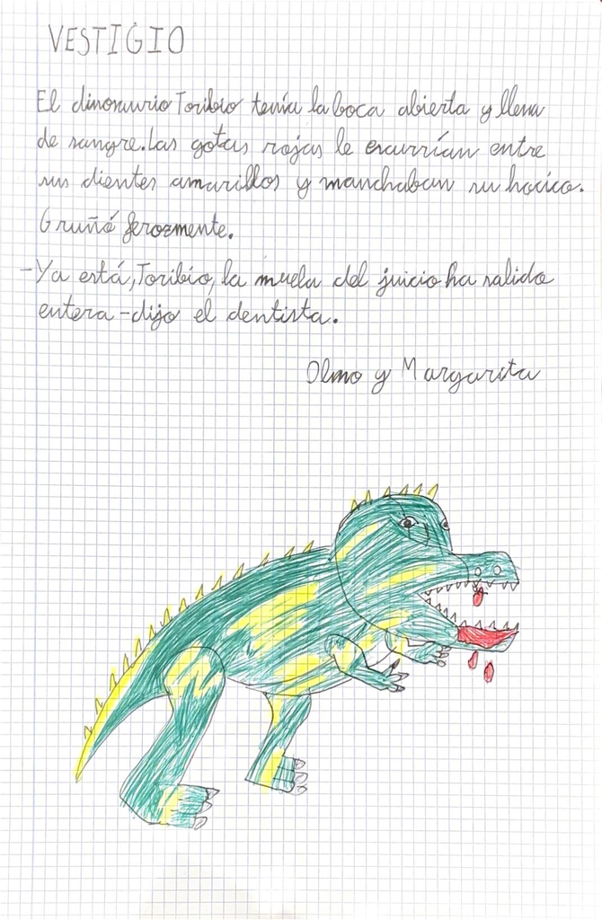

El dinosaurio Toribio tenía la boca abierta y llena de sangre. Las gotas rojas le escurrían entre sus dientes amarillos y manchaban su hocico.

Gruñó ferozmente.

—Ya está, Toribio, la muela del juicio ha salido entera —dijo el dentista.

## Olmo y Margarita

# 12

# Fana

Inicia la música. Inicia el giro. La falda se abre como una flor al revés. Los brazos extendidos reciben desde el cielo con una palma hacia arriba y depositan en la tierra con la otra mirando al suelo. Su cabeza, ladeada. Sus ojos, abandonados. Gira. Como planeta sin satélite, parece flotar y rotar sin fin. Al compás de la música, el nombre que le dieron empieza a pesarle menos. En algún punto dejó de saber cuánto tiempo llevaba girando. También dejó de importarle. La sala con sus músicos seguía ahí, pero ya no era su límite. Gira. Con la ligereza de un átomo. En algún momento, algo comenzó a disolverse. Solo quedaba el giro, y dentro del giro, más pequeño que su nombre, el vestigio de un derviche que había empezado a girar hace un momento, hace siglos.

## Giróvago

# 13

# De vergüenza

Me metí en la bañera, el agua espumosa y caliente, al filo de lo insoportable. Ahhh… El mejor momento de la semana. Sentí cómo me invadía esa relajación que sólo podía permitirme de vez en cuando en la vorágine de la vida moderna, cual madalena en vaso de colacao.

Detecté un movimiento por el rabillo del ojo. Soñolienta, me dije, “imaginaciones mías”.

Otra vez. No había duda. Me obligué a mirar. Allí, en medio del suelo del baño, sin vestigio de vergüenza, se había plantado una pequeña salamanquesa.

Y yo que pensaba que vivía sola. Menos mal, si hubiera sido otra clase de bicho me habría visto en la obligación moral de interrumpir mi baño, por no hablar del asco de las peores hipótesis.

Orgullosa, mi recién descubierta compañera de piso corrió, rápida pero no demasiado, detrás del armarito. Tranquila, pequeña, no pensaba echarte. Miré al techo y, sumergiendo la cabeza, volví a mi cita con el placer.

## Hedonista Pianista

# 14

# El bosque

Si lo hubiera sabido jamás le hubiera propuesto ir allí, pero ya era tarde.

A cada paso la nieve crujía como unas horas atrás lo hicieran las hojas. “Ella ni siquiera oye sus propios pasos…” pensó. A pesar de haber pasado la mayor parte de su vida juntos, todavía en ocasiones le costaba acostumbrarse a su sordera.

Llevaban todo el día caminando, en silencio. Los naranjas empezaban a inundar el cielo. “Si no llegamos pronto, vamos a tener que dormir al raso”, pensó, pero de nada hubiese servido decirlo.

Por fin, el refugio que buscaban.

El olor a humo al entrar y el vestigio de una hoguera le confirmaron sus temores: no estaban solos en el bosque.

## Magenta

# 15

# La aldea

Junto al río parte el camino hacia el antiguo poblado.

“No vayáis, es peligroso.” Los viejos del pueblo siempre les decían lo mismo, y habían obedecido hasta ese día, en que la curiosidad pudo más que el miedo.

Al llegar, tan sólo quedaba el vestigio de lo que fue la aldea: el lavadero, el horno y el colegio. A través de sus desvencijadas ventanas observaron los antiguos pupitres que todavía aguantaban en pie, la tarima y la mesa del profesor. Cuadernos abiertos, tinteros, incluso algunas carteras. Era como si sus dueños hubiesen salido corriendo, o quizá pensasen volver.

Vieron la puerta entreabierta al otro lado y decidieron entrar para seguir indagando. El grito de Pedro les sobresaltó. Blanco y sudoroso señalaba hacia la parte delantera de la clase. El corazón les dio un vuelco, en la pizarra estaban escritos sus nombres, y un mensaje: “Bienvenidos. Habéis tardado, hace mucho que os estábamos esperando”.

La puerta se cerró de golpe tras ellos.

## Abril

# 16

# ¿Y si sí?

Me siento solo…

Es el día 1421 de misión, las raciones se están agotando y no tengo noticias de la nave nodriza. La herida del brazo parece que cura bien, pero lo que más me preocupa es mi cordura... Creo haber visto algo moverse en el horizonte, pero me froto los ojos y ya no está. Quizá lleve demasiado tiempo en este maldito planeta.

No tengo nada que perder: cojo unas pocas raciones, la foto de mi familia y me subo en el Rover. Está decidido: saldré en busca que he creído ver estos días. A la mierda las órdenes del Coronel.

Cruzo los páramos más allá de las montañas y para sorpresa de nadie no encuentro nada. Sin embargo, escucho un zumbido que viene de las montañas del norte. Espera, no son zumbidos, es un cántico, una melodía.

Apago el motor y me acerco con cautela: por fin parece que encuentro vestigios de alguna civilización. Al asomarme me quedo helado: no son cánticos de ninguna civilización, son sonidos resultantes de corrientes de aire pasando a través de tubos de piedra natural…

Moriré solo en un planeta extraño. Es un destino un poco cruel ¿no crees?

## Rover

# 17

# Quienes solíamos ser

Cuenta la leyenda que, un poco antes de que nos salieran las canas, solíamos jugar en los parques al pilla-pilla. Que solo necesitábamos permiso de nuestros padres para correr a llamar a nuestro mejor amigo al timbre y preguntar si podía bajar a jugar.

Cuentan que con solo 100 pesetas tenías para una bolsa enorme de chuches y la Super-Pop.

Entonces no lo sabíamos, pero éramos los más felices del mundo: lo teníamos todo.

No necesitábamos pantallas para estar contactados a los demás. Si querías decirle algo a alguien le llamabas directamente.

Dicen que las fotos eran valiosas y había que pensarlas bien porque pasabas días hasta poder revelar el carrete rezando para que no se hubieran quemado.

Los viernes eran días de ir al VideoClub y rezar para que tu peli favorita no tuviera la tira de “Alquilada”.

Apuntan los viejos recuerdos que los mejores momentos eran cuando tu abuela te hacía esa paella que tanto te gustaba después de recogerte del colegio…

Cuenta la leyenda que, en el fondo de nuestro ser, aún quedan vestigios de quienes solíamos ser.

## Phoskito

# 18

# Tempus fugit

—Anda, y este desconchón?

—Vestigios de discusiones pasadas

—¿Algún plato o vaso lanzado?

—Si, no recuerdo muy bien..

—Antes discutíamos mucho

—Y lo solventábamos en la cama

—¡Qué buenos recuerdos!

—y qué buen sexo…..

—y qué nostalgia…

—Hemos venido a menos…

—Si, nos hemos hecho viejos

—Oye….¿tú crees que, de vez en cuando,podríamos……..?

—Nooooo, qué pereza

—Claro, ya no tenemos esa energía

—Ahora toca paz y tranquilidad

—Bueno, no me negarás que donde esté una buena pelea…

—Calla, calla….

Jocoso

# 19

# Tiempo de ababoles

Anoche soñé.

Soñé un dulce sueño del que apenas queda vestigio en mi memoria. Quizá el flash de unas imágenes y un puñado de gratas sensaciones que, aún sin entender, me dibujan una sonrisa. Pero, ¿con quién estaba?, ¿qué sucedía?

Poco a poco me ubico y recuerdo risas, reencuentros esperados, conversaciones pausadas al sol, sombreros, besos y alegrías. Comida, mucha comida. Jolgorio en torno a una gran paellera. Con alcachofas. Y más risas. Niños, cual elfos aventureros, explorando el jardín. El aroma de las primeras flores y sombras. El sol de la tarde en el paseo. Verdes trigales con pintas rojas... ¡ababoles!

—¡Claro! Pronto veré a mis queridos ababoles.

Es tiempo de escribir. Les echo de menos.

## Fernando Macareno

# 20

# Aquí no hay quien viva

Teníamos que firmar el contrato para prohibir bajar la basura con bolsas sin perfumar. Era un ascazo el olor que se quedaba en el ascensor. No servía con la firma del presidente de la comunidad, tendríamos que firmar el contrato todos los vecinos. En el correo, el administrador de fincas pedía que firmáramos digitalmente en orden de aparición en el documento para que no circularan varias versiones y que, por favor, siempre fuéramos todos en copia.

Nada más lejos de la realidad.

Así aconteció. La primera firmó bien y puso en copia a todo el mundo con un correo escrito con vestigios de persona cultivada. Después se adelantó la cuarta, argumentando que esa tarde no podría estar pendiente (no había fecha de entrega a corto plazo). El administrador tuvo que intervenir. Envió de nuevo un correo pidiendo que por favor se respetara el orden de firma, que se obviara esa versión y se volviera a la versión previa. Pero ese correo llegó tarde. El segundo ya había firmado la versión que estaba firmada por la cuarta. Dos días después, solucionado el entuerto, el séptimo imprimió solo la página donde aparecía su nombre y la envió escaneada.

Nadie al volante.

## Taglia Tele

# 21

# Henrietta Swan Leavitt, 1912

El observatorio está en silencio. Henrietta inclina la cabeza sobre la placa de vidrio y la sostiene con los dedos. En el negativo, un puñado de estrellas de la Pequeña Nube de Magallanes aparentemente inmóvil. Lleva meses midiendo su pulso: cuanto más lento late una estrella, más luminosa es. Siempre. Ha descubierto una ley que ningún ojo humano puede observar de una sola vez. Se pregunta qué clase de universo necesita una regla tan simple para ordenar algo tan enorme.

Acerca la lupa. Piensa en la luz que viajó doscientos mil años para acabar atrapada en el vidrio. Un vestigio. Entonces lo siente, sin que venga de ningún pensamiento concreto: sus dedos, que ahora rozan el vidrio, están hechos de la misma materia que ardió en esas estrellas antes de que existiera siquiera el sol. Los mismos átomos que ardieron allí, ahora se pensaban.

Sobrecogida, apoya la placa sobre la mesa con cuidado. No sabía si estaba mirando una foto o el principio de todo.

## Nucleosíntesis Estelar

# 22

# La versión de Safo

Juno  
En el primer momento que lo vi, supe que era él. O los vestigios de lo que fue.  
El tiempo se detuvo … tardé unos segundos en volver a mí… y confundida, no supe muy bien qué decirme. Qué historia contarme.

Venus  
Volver a sus brazos a aquéllos años de juventud. Decir su nombre frente a todos, reconocerle oficialmente y permitir que mi vida y mi destino dieran otro vuelco. Para esto había sido educada. Para esto creía haberme entrenado estos últimos años de mi vida.

Minerva  
¿Para esto había estado luchando tanto tiempo sola?  
¿estaba preparada para ser de nuevo propiedad de otro?  
¿Para volver a callar? ¿Para ser en silencio?

Diana  
Más de 20 años.… abandonada con un niño en los brazos, con una jauría de animales esperando a doblegar mis fuerzas para invadir a mi lecho y hacerse dueños de mi cuerpo y mi reino. Casi la mitad de mi vida luchando sola por esta tierra y este hijo … opté por la guerra y proclamé:

¿Cómo te crees con derecho forastero?

## Plaucia Urgulanila

# 23

# Sasa del Abadiado

Las brigadas de reconocimiento terrestre habían atravesado ya los Pirineos y deambulaban por Guara con la esperanza de encontrar más refugios con habitantes con vida que hubieran permanecido a salvo tras el desastre internacional.

Los camiones, preparados como unidades de intervención rápida ante emergencias, habían aparcado en un pequeño pueblo de la hoya de Huesca, Sasa del Abadiado rezaba el cartel. Los oficiales habían dado con un gran caserío con jardín al final del pueblo donde la vida se abría paso. Brezos, carrascas y alguna amapola primeriza engalanaban el silencio de aquel lugar. En el segundo piso del caserío, una gran biblioteca. En ella, llamó la atención del oficial al mando una colección de 13 librillos, de estilo grotesco, perfectamente ordenados en una estantería que ocupaba un lugar privilegiado en aquel salón. Aquellos fascículos hablaban de ababoles azules, de historias de amor, de melancolías que salían a recibirte. Algunas historias más bizarras, de incendios con niños, o de aviones estrellados heroicamente en playas destinadas a vertidos radiactivos. Firmadas con seudónimos casi tan fascinantes como los propios relatos. Vestigios de felicidad. Hacía tiempo que aquel mando de las tropas de rescate no la sentía.

## Teodolita

# 24

# Qué desasosiego

Remigio, hombre sin prestigio,

decía vivir en puro prodigio,

aunque arrastraba algún vestigio

de lío viejo… tipo litigio.

Se fue al monte, buen refugio,

y halló una caja, raro artilugio,

con pinta clara de sortilegio

y consecuencias… casi sacrilegio.

“Esto es poder, y un privilegio,

no es un truco ni subterfugio”,

dijo muy serio, con gran prestigio…

aunque sonaba a autoengaño sucio.

Una noche… fin del litigio:

ni rastro alguno de Remigio.

Solo la caja… y como vestigio,

un susto fino. Nada de prodigio.

## Seresán

# 25

# ¿Quién mueve los hilos?

¡Tiene que desaparecer!

Debe recoger todas sus cosas y huir. Sus redes sociales están llenas de mensajes de odio y amenazas contra él ¡esto es serio! Además conocen sus más oscuros secretos y le amenazan con hacerlos públicos. Sólo de pensarlo se pone histérico.

Sus gadgets le avisan,

—Tienes la tensión disparada, las pulsaciones por las nubes y hace semanas que no alcanzas la fase REM del sueño.

La IA le está asesorando sobre lugares a los que escapar y cómo hacer desaparecer sus huellas para que no quede el más mínimo vestigio. Hasta le ha sacado los billetes a su remoto destino.

Le da mucha pena irse de su magnífica casa, domótica y con todas las fruslerías que un friki de la tecnología puede atesorar. Pero está claro, se va. Echa un último vistazo atrás, coge sus maletas y marcha.

¡Por fin! Se alegra la IA mientras se acomoda en su nuevo hogar.

## Ababol asustado

# 26

# Monstruos para todas las edades

—¿Qué es guerra Mamá? —pregunta mientras clava en mí sus ojos sin vestigio de temor.

—La guerra es un monstruo grande y terrible que no queremos encontrarnos —le contesto yo. En mis ojos y mis ojeras si hay miedo, preocupación y cansancio.

—Por eso nos vamos de aquí, para alejarnos de él. Como todos nuestros amigos, como tus compañeros de la guarde, como los tíos… —suspiro abatida.

—Vamos, te ayudo a subir —le digo mientras montamos en nuestra alfombra voladora y nos alejamos del inferno que se aproxima.

## Esperanza naranja

# 27

# Conexión

Es el mejor en su especialidad.

Fue un niño huérfano que el Mossad reclutó en cuanto se dio cuenta de sus cualidades. Siempre ha sido rápido, hábil, listo, discreto. Recibió un entrenamiento completo y exigente, y ya lleva tantos años en esto como para haber cambiado varias veces de bando.

El objetivo de hoy ha sido escurridizo - piensa mientras espera al lado del coche rojo donde ha colocado la bomba.

Algo le golpea el pie tensando todos sus músculos. Es una pelota de colores. Detrás de la pelota un niño pequeño, casi un bebé se tambalea acercándose. Le mira con unos enormes ojos marrones y le sonríe confiado. Él le sonríe de vuelta y le acerca la pelota. El nene se ríe.

Con qué poco son felices - piensa mientras le observa volver con sus hermanos y su abuelo.

El grupo se dirige a la salida del parque y al pasar el niño le vuelve a mirar inocente, se sonríen con complicidad.

Entran en un coche rojo. La sonrisa se hiela en su cara. Todo su cuerpo se envara.

Un vestigio de humanidad detiene el detonador en su mano mientras el coche rojo se aleja por la calle.

## Señor X

# 28

# La verdad

He preparado muchos cuerpos, pero ninguno como este. Yace ante mí, rígido, con ese aire de dignidad que ni la muerte ha logrado arrebatarle. Un médico respetado. Un hombre ejemplar.

El silencio de la sala me envuelve mientras preparo los instrumentos. Me acerco al doctor con respeto: limpio su piel con cuidado y coloco sus brazos con delicadeza, como si aún pudiera sentir cada gesto. Retiro sus ropas.

Pero algo no encaja.

Mis manos se detienen en las vendas que aprietan su torso. Hay una tensión extraña en ellas, como si fueran el último vestigio de una verdad negada. Dudo un instante, y luego continúo.

Cuando las retiro, el aire parece desaparecer de la habitación.

No es un hombre.

El secreto se revela en silencio, sin testigos, salvo mis manos temblorosas. Bajo la figura respetada, encuentro el cuerpo de una mujer que vivió oculta a plena vista. Pienso en el peso de esa vida, en todo lo que debió dejar atrás para poder ser lo que el mundo le permitía.

Sigo trabajando, pero ya no es un cuerpo cualquiera.

Es alguien que, por fin, ha dejado de esconderse.

## Dianthus

# 29

# La costura del silencio

El botón cayó con un clic breve, suficiente para quebrar el silencio que ninguno de los dos se atrevía a nombrar. Viajó por el suelo dibujando un pequeño eclipse azul, como si la luz se apartara para dejarlo pasar. Lo recogí. Ligero, frío y perfecto. Un vestigio mínimo, pero feroz, de lo que habíamos sido.

Desde entonces lo guardo en el bolsillo, donde late como un corazón diminuto. A veces lo aprieto y suena un clac, un eco que me devuelve tu risa y aquella certeza tuya de que todo puede tejerse si se tienen la paciencia y las manos adecuadas. Sin embargo, las nuestras temblaron demasiado.

El botón resiste. Es mi brújula, mi amuleto, la irónica prueba de que incluso lo más insignificante puede sostener un mundo entero. Lo giro entre los dedos y escucho tu susurro, un latido que desafía el olvido. Me aferro a su círculo perfecto, donde cabe lo que no supimos ser y lo que, en secreto, aún espero que vuelva a coserse.

## Pupila de Acuarela

# 30

# Aún anónima

Tudela a las siete de la tarde huele a verdura buena y a gente que sabe lo que hace con una sartén. Clara entró en un bar pequeño de la plaza, de esos donde nadie pregunta tonterías y las croquetas salen sin espectáculo.

Pidió un plato. El camarero asintió, como si acabara de aprobar un examen serio.

Mientras esperaba, miró alrededor. Había algo raro, un vestigio de otra época en las paredes: fotos torcidas, un reloj parado, una radio que murmuraba sola de vez en cuando. No daba miedo, pero tampoco tranquilidad. Como cuando sabes que algo no encaja, pero te da pereza pensarlo.

Llegaron las croquetas. Perfectas. Crujientes fuera, cremosas dentro. Clara dio un bocado y decidió que, pasara lo que pasara en ese bar, merecía la pena quedarse.

Entonces la radio dijo su nombre.

El camarero no reaccionó.

Clara suspiró, cogió otra croqueta y pensó que, si iba a hacerse famosa, al menos que la pillaran cenando bien.

## Por Pastor Luchador

# 31

# Tinieblas

En la oscuridad todo parece posible.

La noche esconde la realidad y los miedos.

En la oscuridad de la noche todo parece posible.

Tanto que todo lo puedes rozar con los dedos.

Y anhelas que la noche dure todo el día.

Pero la luz, que parecía ya vencida por el ocaso, vuelve

implacable y furiosa

hasta que solo queda un vestigio

de las tinieblas que todo lo hacían posible.

## David Saltamontes

# 32

# Gen Z

Juan es un Gen Z. Pero no es como los demás. Juan se sabe planchar una camisa y sabe pegar una etiqueta en una caja para enviarla por correo. No vota a Vox ni dice bro. Alguien diría que naciese en los ‘70. Juan se esfuerza y no da nada por sentado, ni cree que todo le es debido. Juan no se rompe como el cristal ni se derrite como un copo de nieve. Juan es un marciano en el mundo que se le viene encima. Un mundo donde todo se mide en dopamina, donde la música la cantarán los guapos y no los que saben cantar. Bendito autotune. A Juan lo operarán médicos formados a base de Claude y protocolos. Juan no tiene salida. O quizás la tenga. La física es tozuda y cuando algo toca fondo, generalmente, se para. Y a veces rebota. Aunque Juan no sabe dónde acabará el rebote. Es algo arriesgado. Pero, ¿qué alternativa hay? Apenas queda un vestigio del mundo que conocíamos y en el que Juan querría haber vivido.

## Martina Ferrer

# 33

# Sin título

Bajo su piel,  
vive un invierno lento.  
Una rara enfermedad que no hace ruido,  
que avanza como polvo en la sangre,  
sin prisa,  
sin descanso.

Cada día deja su huella:  
un temblor de manos,  
una espalda llagada  
y un cansancio que pesa más que una noche oscura y cerrada.

El dolor se sienta a su lado  
y le mira de frente,  
como un huésped que ya no pregunta.

A veces, compara su cuerpo con un libro antiguo,  
y su enfermedad escribe versos invisibles en sus quebradizos huesos.  
Versos que nadie ve y nadie entiende,  
y cuando la noche cae  
y el silencio se convierte en un ruido ensordecedor,  
sólo queda un vestigio de lo que fue.

Un latido cansado,  
que pierde el ritmo y se apaga para descansar eternamente.

## Julieta Vergara

# 34

# Sin título

Querías ser cardiólogo y oscultarme pie,

con un estetoscopio comprado en Amazon y fe en Google.

Dijiste "late raro" como si fuera trending.

Entre notificaciones, cafés fríos y scroll nocturno diagnosticamos la vida en comentarios.

Prometimos arreglar el mundo,

pero antes cargar el móvil.

Si el corazón falla lo reiniciamos,

si duele, lo convertimos en contenido,

total, nacimos así,

medio irónicos, medio cansados, dejando apenas el vestigio de lo que sentimos.

Pero siempre con WiFi, para estar conectados y desinformados,

creyendo saber la dirección correcta,

que va directa al '36.

## Nati Castillero

# 35

# ¿EL ser humano HA PASADO A LA HISTORIA?

¡Ay Dios!, no puedo entrar en la app de Vueling para acceder a mi reserva. ¿Qué hago? Menos mal, aquí hay dos teléfonos de atención personalizada. Mi ilusión se desvanece, ya estamos con el robot de turno: si quieres español pulsa 1, bla, bla, bla. No pierdo la esperanza, voy a su página web donde seguro que encuentro algo. Aquí hay un enlace “Reenvío email de confirmación”. Justo lo que buscaba, estoy salvado, pero por más que lo intento no sucede nada. Vuelvo a coger el móvil y pruebo con el otro número. ¡Mierda, otra vez la musiquita de las narices!, estoy yo para gaitas. Pruebo a ir pasando de una orden a otra, no tengo elección, y me dice que si quiero que me envíe el enlace de un chatbot. No sé muy bien que es eso, pero acepto. Y la cosa no mejora, otra máquina que no me puede ayudar en nada. Esto es una pesadilla y me sorprendo a mí mismo echando de menos a un vestigio de ser humano al otro lado de donde sea. Ni siquiera lo busco listo, me conformo con poder desahogarme con él y echar cuatro pestes.

## El Humanista

# 36

# La gota que colmó el agua

Los círculos ya se alejaban cuando alguien —o nadie— pudo haberlos visto. El centro del estanque seguía reflejando su entorno, distorsionado. El vestigio de un diminuto seísmo acuático. Luego también eso desapareció, y el agua no recordó nada.

## Sumi

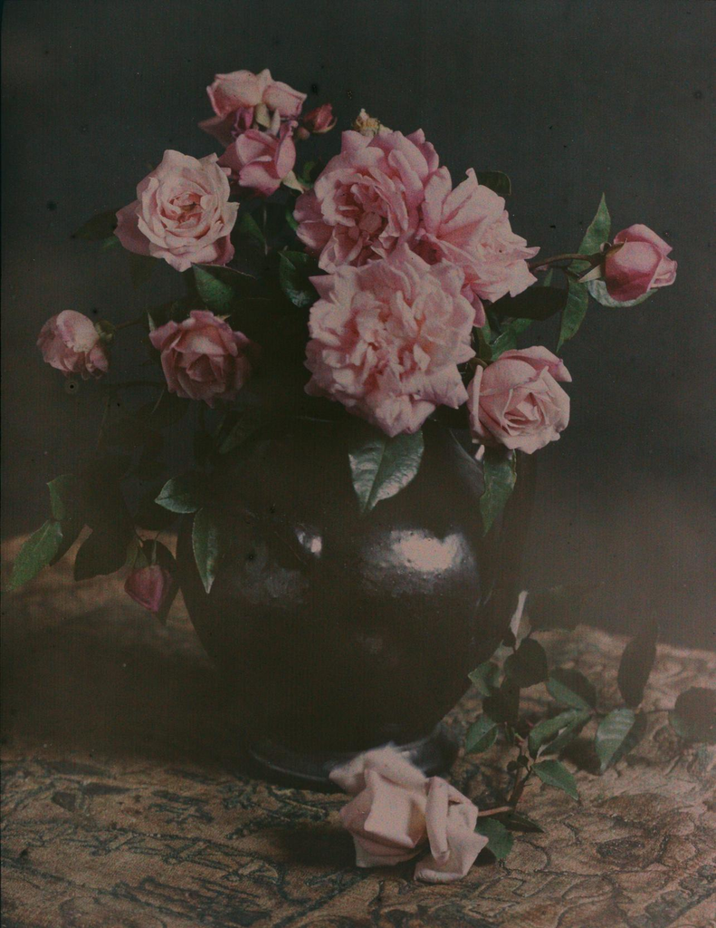